# 임종언-배유나

과제내용

- Titanic competition의 최우수 Kernel로 선정된 아래 두 Kernel을 모두 참고하여, H백화점 고객의 성별을 예측하시오. (모형 평가지표는 ROC-AUC를 사용) https://www.kaggle.com/ash316/eda-to-prediction-dietanic

  https://www.kaggle.com/yassineghouzam/titanic-top-4-with-ensemble-modeling

데이터

- 첨부한 학습데이터(hds_train.csv)와 평가데이터(hds_test.csv)를 이용하여 과제 수행
- 학습데이터의 gender 필드(class 변수)에서 '0'은 여자, '1'은 남자를 나타냄.

제출물

- "분석과정을 아주 상세하게 설명한" Jupyter notebook(화일명: 이름1-이름2.ipynb)과 동일한 내용의 HTML(화일명: 이름1-이름2.html)
- 평가데이터에 대한 성별 예측결과를 저장한 submission 화일(화일명: 이름1-이름2-submit.csv). 형식은 첨부한 sample_submission.csv 참조.
- 위와 같은 총3개 화일을 압축하지 말고 이메일로 제출

유의사항

- 마감시간 내에 제출한 과제만 평가함.
- 반드시, 담당교수 이메일(www4u@kookmin.ac.kr)로 제출해야 하고, 메일 제목은 "팀과제(1차) 이름1-이름2"로 할 것.

```python
import pandas as pd
from pandas import Series, DataFrame
import numpy as np
import seaborn as sns
import matplotlib.pyplot as plt
plt.style.use('fivethirtyeight')
import warnings
warnings.filterwarnings('ignore')
%matplotlib inline
```

```python
plt.rc('font', family='Malgun Gothic')
plt.rc('axes', unicode_minus=False)
```

```python
test = pd.read_csv('hds_test.csv', encoding='CP949',engine='python')
train = pd.read_csv('hds_train.csv', encoding='CP949',engine='python')
sample = pd.read_csv('sample_submission.csv', encoding='CP949',engine='python')
```

```python
test.head()
```

|  | custid | 총구매액 | 총구매건수 | 평균구매액 | 최대구매액 | 총할인액 | 평균할인액 | 평균할부개월수 | 최대할부개월수 | 구입브랜드수 | ... | 주말방문비율 | 봄구매비율 | 여름구매비율 | 가을구매비율 | 겨울구매비율 | 저녁구매비율 | 주구매브랜드 | 주구매코너 | 주구매시간 | 주방문요일 |
| --- | --- | --- | --- | --- | --- | --- | --- | --- | --- | --- | --- | --- | --- | --- | --- | --- | --- | --- | --- | --- | --- |
| 0 | 30000 | 2078240 | 27 | 76971.851852 | 448000 | 77780 | 2880.740741 | 1.222222 | 3 | 16 | ... | 0.555556 | 0.333333 | 0.185185 | 0.148148 | 0.333333 | 0.518519 | 식품 | 진케주얼 | 18.0 | 일 |
| 1 | 30001 | 4158320 | 27 | 154011.851852 | 812000 | 118070 | 4372.962963 | 1.740741 | 3 | 19 | ... | 0.740741 | 0.333333 | 0.333333 | 0.111111 | 0.222222 | 0.222222 | 식품 | 캐쥬얼구두 | 17.0 | 일 |
| 2 | 30002 | 8007256 | 100 | 80072.560000 | 410000 | 315050 | 3150.500000 | 2.080000 | 3 | 42 | ... | 0.300000 | 0.250000 | 0.260000 | 0.270000 | 0.220000 | 0.100000 | 에스티로더 | 수입종합화장품 | 12.0 | 토 |
| 3 | 30003 | 1367820 | 43 | 31809.767442 | 138000 | 19090 | 443.953488 | 1.372093 | 3 | 28 | ... | 0.186047 | 0.232558 | 0.139535 | 0.465116 | 0.162791 | 0.255814 | 식품 | 문화 | 14.0 | 금 |
| 4 | 30004 | 2890471 | 55 | 52554.018182 | 1110000 | 6780 | 123.272727 | 1.327273 | 3 | 23 | ... | 0.254545 | 0.036364 | 0.418182 | 0.381818 | 0.163636 | 0.381818 | 식품 | 완구 | 19.0 | 목 |

5 rows × 23 columns

```python
train.head()
```

|  | custid | 총구매액 | 총구매건수 | 평균구매액 | 최대구매액 | 총할인액 | 평균할인액 | 평균할부개월수 | 최대할부개월수 | 구입브랜드수 | ... | 봄구매비율 | 여름구매비율 | 가을구매비율 | 겨울구매비율 | 저녁구매비율 | 주구매브랜드 | 주구매코너 | 주구매시간 | 주방문요일 | gender |
| --- | --- | --- | --- | --- | --- | --- | --- | --- | --- | --- | --- | --- | --- | --- | --- | --- | --- | --- | --- | --- | --- |
| 0 | 0 | 1742000 | 11 | 158363.636364 | 455000 | 174200 | 15836.363636 | 2.818182 | 3 | 7 | ... | 0.090909 | 0.363636 | 0.272727 | 0.272727 | 0.818182 | 크리니크 | 수입종합화장품 | 19.0 | 일 | 1 |
| 1 | 1 | 2772100 | 26 | 106619.230769 | 393000 | 56630 | 2178.076923 | 2.461538 | 3 | 19 | ... | 0.384615 | 0.346154 | 0.230769 | 0.038462 | 0.115385 | 겐조수입의류 | 수입부띠끄 | 16.0 | 토 | 1 |
| 2 | 2 | 3750850 | 11 | 340986.363636 | 1416000 | 255090 | 23190.000000 | 3.454545 | 12 | 7 | ... | NaN | 0.272727 | 0.454545 | 0.272727 | 0.363636 | 노티카 | 가전특정 | 19.0 | 수 | 1 |
| 3 | 3 | 2300500 | 30 | 76683.333333 | 621000 | 91660 | 3055.333333 | 2.666667 | 5 | 21 | ... | 0.300000 | 0.400000 | 0.100000 | 0.200000 | 0.400000 | 라코스테 | 골프(LC) | 18.0 | 목 | 0 |
| 4 | 4 | 1045000 | 4 | 261250.000000 | 560000 | 21800 | 5450.000000 | 4.500000 | 10 | 4 | ... | NaN | 1.000000 | NaN | NaN | 0.000000 | 리츠 | 니트웨어 | 14.0 | 목 | 0 |

5 rows × 24 columns

```python
sample.head()
```

|  | custid | gender |
| --- | --- | --- |
| 0 | 30000 | 0.5 |
| 1 | 30001 | 0.5 |
| 2 | 30002 | 0.5 |
| 3 | 30003 | 0.5 |
| 4 | 30004 | 0.5 |

```python
print( train.shape , test.shape)
```

```
(30000, 24) (19995, 23)
```

<font color = "#3232FF">

# 1. 결측치 처리

- 1-1. 봄여름가을겨울구매비율
- 1-2. 주구매시간
  - 1-2-1. 선형회귀모델
  - 1-2-2. 범주별 최빈값 처리

```python
train.info()
```

```
<class 'pandas.core.frame.DataFrame'>
RangeIndex: 30000 entries, 0 to 29999
Data columns (total 24 columns):
custid     30000 non-null int64
총구매액       30000 non-null int64
총구매건수      30000 non-null int64
평균구매액      30000 non-null float64
최대구매액      30000 non-null int64
총할인액       30000 non-null int64
평균할인액      30000 non-null float64
평균할부개월수    30000 non-null float64
최대할부개월수    30000 non-null int64
구입브랜드수     30000 non-null int64
브랜드편중도     30000 non-null float64
수입상품구매율    30000 non-null float64
내점일수       30000 non-null int64
주말방문비율     30000 non-null float64
봄구매비율      25942 non-null float64
여름구매비율     23859 non-null float64
가을구매비율     24264 non-null float64
겨울구매비율     24501 non-null float64
저녁구매비율     30000 non-null float64
주구매브랜드     30000 non-null object
주구매코너      30000 non-null object
주구매시간      26316 non-null float64
주방문요일      30000 non-null object
gender     30000 non-null int64
dtypes: float64(12), int64(9), object(3)
memory usage: 5.5+ MB
```

<font color = "#3232FF">

## 1-1 봄,여름,가을,겨울구매비율

```python
season = train[['봄구매비율','여름구매비율','가을구매비율','겨울구매비율']];season.head(20)
```

|  | 봄구매비율 | 여름구매비율 | 가을구매비율 | 겨울구매비율 |
| --- | --- | --- | --- | --- |
| 0 | 0.090909 | 0.363636 | 0.272727 | 0.272727 |
| 1 | 0.384615 | 0.346154 | 0.230769 | 0.038462 |
| 2 | NaN | 0.272727 | 0.454545 | 0.272727 |
| 3 | 0.300000 | 0.400000 | 0.100000 | 0.200000 |
| 4 | NaN | 1.000000 | NaN | NaN |
| 5 | 0.187500 | 0.406250 | 0.375000 | 0.031250 |
| 6 | 0.290323 | 0.193548 | 0.451613 | 0.064516 |
| 7 | 0.028571 | 0.428571 | 0.200000 | 0.342857 |
| 8 | 0.111111 | 0.555556 | 0.222222 | 0.111111 |
| 9 | 0.186441 | 0.288136 | 0.305085 | 0.220339 |
| 10 | 0.166667 | 0.458333 | 0.208333 | 0.166667 |
| 11 | 0.227273 | 0.181818 | 0.363636 | 0.227273 |
| 12 | 0.785714 | NaN | 0.178571 | 0.035714 |
| 13 | 0.178295 | 0.271318 | 0.248062 | 0.302326 |
| 14 | 0.166667 | 0.500000 | 0.333333 | NaN |
| 15 | 0.413793 | 0.287356 | 0.068966 | 0.229885 |
| 16 | 0.350000 | 0.300000 | 0.250000 | 0.100000 |
| 17 | 0.260870 | 0.521739 | 0.130435 | 0.086957 |
| 18 | 0.229730 | 0.121622 | 0.324324 | 0.324324 |
| 19 | 0.411765 | 0.058824 | 0.058824 | 0.470588 |

```python
season['sum_all'] = season['봄구매비율']+season['여름구매비율']+season['가을구매비율']+season['겨울구매비율'];season.head(10)
```

|  | 봄구매비율 | 여름구매비율 | 가을구매비율 | 겨울구매비율 | sum_all |
| --- | --- | --- | --- | --- | --- |
| 0 | 0.090909 | 0.363636 | 0.272727 | 0.272727 | 1.0 |
| 1 | 0.384615 | 0.346154 | 0.230769 | 0.038462 | 1.0 |
| 2 | NaN | 0.272727 | 0.454545 | 0.272727 | NaN |
| 3 | 0.300000 | 0.400000 | 0.100000 | 0.200000 | 1.0 |
| 4 | NaN | 1.000000 | NaN | NaN | NaN |
| 5 | 0.187500 | 0.406250 | 0.375000 | 0.031250 | 1.0 |
| 6 | 0.290323 | 0.193548 | 0.451613 | 0.064516 | 1.0 |
| 7 | 0.028571 | 0.428571 | 0.200000 | 0.342857 | 1.0 |
| 8 | 0.111111 | 0.555556 | 0.222222 | 0.111111 | 1.0 |
| 9 | 0.186441 | 0.288136 | 0.305085 | 0.220339 | 1.0 |

<font color = "#3232FF">

각 행에대한 봄,여름,가을,겨울구매비율을 본 결과 1의 값을 나타내므로

각 결측치는 구매한적이 없는 즉, 0의 값을 나타낸다는 것을 알 수 있다.

그렇기때문에 결측치를 0으로 채웠다.

```python
train[['봄구매비율','여름구매비율','가을구매비율','겨울구매비율']] = train[['봄구매비율','여름구매비율','가을구매비율','겨울구매비율']].fillna(0)
```

```python
test[['봄구매비율','여름구매비율','가을구매비율','겨울구매비율']] = test[['봄구매비율','여름구매비율','가을구매비율','겨울구매비율']].fillna(0)
```

<font color = "#3232FF">

# 1-2 주구매시간

<font color = "#3232FF">

#### 주구매시간의 결측치를 채우기 위해 단순 최빈값보다 우선 주구매시간과 다른 변수들의 상관성을 확인하였다.

```python
pd.DataFrame(train.corr().주구매시간).sort_values(by=['주구매시간'],axis=0,ascending=False)
```

|  | 주구매시간 |
| --- | --- |
| 주구매시간 | 1.000000 |
| 저녁구매비율 | 0.620869 |
| 주말방문비율 | 0.095200 |
| 겨울구매비율 | 0.040655 |
| 최대할부개월수 | 0.035002 |
| 구입브랜드수 | 0.033383 |
| 내점일수 | 0.030167 |
| 총할인액 | 0.025091 |
| 총구매건수 | 0.015461 |
| 평균할인액 | 0.009175 |
| 브랜드편중도 | 0.006295 |
| 가을구매비율 | 0.001782 |
| 평균할부개월수 | 0.000473 |
| custid | -0.001319 |
| 총구매액 | -0.001514 |
| 최대구매액 | -0.011338 |
| 봄구매비율 | -0.011910 |
| 수입상품구매율 | -0.025284 |
| 여름구매비율 | -0.027675 |
| 평균구매액 | -0.029397 |
| gender | -0.100922 |

<font color = "#3232FF">

그 결과 주구매시간과 저녁구매비율은 0.6208의 상관계수를 가진다는 것을 알게되었고

주구매시간의 결측치를 채우기위하여 높은 상관성을 보이는 저녁구매비율을 활용하기로 하였다.

<font color = "#3232FF">

## 1-2-1 : 선형회귀모델에 적합

```python
from sklearn.linear_model import LinearRegression
from sklearn.model_selection import train_test_split

new = train[['주구매시간','저녁구매비율']]
nan_train = new[pd.notnull(new['주구매시간']) == True]
nan_test = new[pd.notnull(new['주구매시간']) != True]

print( nan_train.shape , nan_test.shape)
nan_train.head()
```

```
(26316, 2) (3684, 2)
```

|  | 주구매시간 | 저녁구매비율 |
| --- | --- | --- |
| 0 | 19.0 | 0.818182 |
| 1 | 16.0 | 0.115385 |
| 2 | 19.0 | 0.363636 |
| 3 | 18.0 | 0.400000 |
| 4 | 14.0 | 0.000000 |

```python
dfy = nan_train['주구매시간']
dfX = nan_train.drop('주구매시간',1)

X_train, X_test, y_train, y_test = train_test_split(dfX, dfy, test_size=0.3, random_state=0)
```

```python
model = LinearRegression()
model.fit(X_train, y_train)
```

```
LinearRegression(copy_X=True, fit_intercept=True, n_jobs=None,
         normalize=False)
```

```python
model.score(X_test, y_test)
```

```
0.3976114477616961
```

<font color = "#3232FF">

### R^2값이 0.3976의 값으로 주구매시간을 나타내는데 적합하지 않다는 결론을 내리게 되었고 선형모델을 시각화 해보았다.

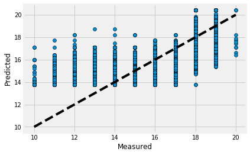

```python
y_pred = model.predict(X_test)
plt.scatter(y_test, y_pred, edgecolors=(0, 0, 0))
plt.plot([y_test.min(), y_test.max()], [y_test.min(), y_test.max()], 'k--', lw=4)
plt.xlabel('Measured')
plt.ylabel('Predicted')
```

<font color = "#3232FF">

# 1-2-2 : 저녁구매비율을 범주화하여 저녁구매비율 별 평균 주구매시간을 구하여 결측값 처리

```python
nan_train_new = nan_train.apply(lambda x: round(x,2)) ; nan_train_new.head(10)
```

|  | 주구매시간 | 저녁구매비율 |
| --- | --- | --- |
| 0 | 19.0 | 0.82 |
| 1 | 16.0 | 0.12 |
| 2 | 19.0 | 0.36 |
| 3 | 18.0 | 0.40 |
| 4 | 14.0 | 0.00 |
| 5 | 11.0 | 0.38 |
| 6 | 16.0 | 0.26 |
| 7 | 17.0 | 0.14 |
| 9 | 12.0 | 0.41 |
| 10 | 11.0 | 0.08 |

```python
stand = nan_train_new.groupby(['저녁구매비율'])['주구매시간'].mean().reset_index() ; stand.head(10)
```

|  | 저녁구매비율 | 주구매시간 |
| --- | --- | --- |
| 0 | 0.00 | 13.723312 |
| 1 | 0.01 | 13.073333 |
| 2 | 0.02 | 13.495751 |
| 3 | 0.03 | 13.735230 |
| 4 | 0.04 | 13.780335 |
| 5 | 0.05 | 13.774757 |
| 6 | 0.06 | 14.026923 |
| 7 | 0.07 | 14.075789 |
| 8 | 0.08 | 14.166972 |
| 9 | 0.09 | 14.315682 |

```python
stand_apply = train[pd.notnull(train['주구매시간']) != True]['저녁구매비율'].reset_index().apply(lambda x: round(x,2))
stand_apply.head(10)
```

|  | index | 저녁구매비율 |
| --- | --- | --- |
| 0 | 8 | 0.17 |
| 1 | 11 | 0.14 |
| 2 | 18 | 0.08 |
| 3 | 23 | 0.19 |
| 4 | 24 | 0.67 |
| 5 | 53 | 0.17 |
| 6 | 55 | 0.20 |
| 7 | 66 | 0.04 |
| 8 | 82 | 0.14 |
| 9 | 91 | 0.00 |

```python
a = pd.merge(stand_apply,stand,on='저녁구매비율')

import math
a['주구매시간'] = a['주구매시간'].apply(lambda x: math.ceil(x))
a.info()
```

```
<class 'pandas.core.frame.DataFrame'>
Int64Index: 3683 entries, 0 to 3682
Data columns (total 3 columns):
index     3683 non-null int64
저녁구매비율    3683 non-null float64
주구매시간     3683 non-null int64
dtypes: float64(1), int64(2)
memory usage: 115.1 KB
```

```python
a.head()
```

|  | index | 저녁구매비율 | 주구매시간 |
| --- | --- | --- | --- |
| 0 | 8 | 0.17 | 15 |
| 1 | 53 | 0.17 | 15 |
| 2 | 335 | 0.17 | 15 |
| 3 | 639 | 0.17 | 15 |
| 4 | 1164 | 0.17 | 15 |

```python
for i in range(0,len(a)):
    num = train['custid'][a['index'][i]]
    train.loc[num,'주구매시간'] = a['주구매시간'][i]
```

<font color = "#3232FF">

### Train셋에서 결측치를 채우는 중 0.97의 값을 가지는 데이터가 없어 하나의 행을 결측처리하지 못하였다.

```python
train[pd.notnull(train['주구매시간']) != True]
```

|  | custid | 총구매액 | 총구매건수 | 평균구매액 | 최대구매액 | 총할인액 | 평균할인액 | 평균할부개월수 | 최대할부개월수 | 구입브랜드수 | ... | 봄구매비율 | 여름구매비율 | 가을구매비율 | 겨울구매비율 | 저녁구매비율 | 주구매브랜드 | 주구매코너 | 주구매시간 | 주방문요일 | gender |
| --- | --- | --- | --- | --- | --- | --- | --- | --- | --- | --- | --- | --- | --- | --- | --- | --- | --- | --- | --- | --- | --- |
| 18066 | 18066 | 666208 | 40 | 16655.2 | 98000 | 9550 | 238.75 | 1.1 | 3 | 6 | ... | 0.3 | 0.125 | 0.25 | 0.325 | 0.975 | 식품 | 야채 | NaN | 금 | 0 |

1 rows × 24 columns

<font color = "#3232FF">

그렇기에 0.97와 가까운 0.96 , 0.98의 값을 확인하였고

저녁구매비율이 0.98인 주구매시간은 나오지않았고

0.96의 평균 주구매시간이 18시인점을 이용하여

남은 하나의 결측치를 채웠다.

```python
nan_train_new[nan_train_new['저녁구매비율']==0.96]
```

|  | 주구매시간 | 저녁구매비율 |
| --- | --- | --- |
| 9580 | 18.0 | 0.96 |
| 15428 | 19.0 | 0.96 |
| 20115 | 18.0 | 0.96 |

```python
train = train.fillna(18)
```

<font color = "#3232FF">

# 최종적으로 결측치의 유무를 확인하였다.

```python
train.info()
train.isnull().sum()
```

```
<class 'pandas.core.frame.DataFrame'>
RangeIndex: 30000 entries, 0 to 29999
Data columns (total 24 columns):
custid     30000 non-null int64
총구매액       30000 non-null int64
총구매건수      30000 non-null int64
평균구매액      30000 non-null float64
최대구매액      30000 non-null int64
총할인액       30000 non-null int64
평균할인액      30000 non-null float64
평균할부개월수    30000 non-null float64
최대할부개월수    30000 non-null int64
구입브랜드수     30000 non-null int64
브랜드편중도     30000 non-null float64
수입상품구매율    30000 non-null float64
내점일수       30000 non-null int64
주말방문비율     30000 non-null float64
봄구매비율      30000 non-null float64
여름구매비율     30000 non-null float64
가을구매비율     30000 non-null float64
겨울구매비율     30000 non-null float64
저녁구매비율     30000 non-null float64
주구매브랜드     30000 non-null object
주구매코너      30000 non-null object
주구매시간      30000 non-null float64
주방문요일      30000 non-null object
gender     30000 non-null int64
dtypes: float64(12), int64(9), object(3)
memory usage: 5.5+ MB
```

```
custid     0
총구매액       0
총구매건수      0
평균구매액      0
최대구매액      0
총할인액       0
평균할인액      0
평균할부개월수    0
최대할부개월수    0
구입브랜드수     0
브랜드편중도     0
수입상품구매율    0
내점일수       0
주말방문비율     0
봄구매비율      0
여름구매비율     0
가을구매비율     0
겨울구매비율     0
저녁구매비율     0
주구매브랜드     0
주구매코너      0
주구매시간      0
주방문요일      0
gender     0
dtype: int64
```

<font color = "#3232FF">

# 위와같은 과정을 Test셋에도 적용하였다.

```python
test[pd.notnull(test['주구매시간']) != True].info() # test데이터에 주구매시간 2488개의 결측값
```

```
<class 'pandas.core.frame.DataFrame'>
Int64Index: 2488 entries, 6 to 19983
Data columns (total 23 columns):
custid     2488 non-null int64
총구매액       2488 non-null int64
총구매건수      2488 non-null int64
평균구매액      2488 non-null float64
최대구매액      2488 non-null int64
총할인액       2488 non-null int64
평균할인액      2488 non-null float64
평균할부개월수    2488 non-null float64
최대할부개월수    2488 non-null int64
구입브랜드수     2488 non-null int64
브랜드편중도     2488 non-null float64
수입상품구매율    2488 non-null float64
내점일수       2488 non-null int64
주말방문비율     2488 non-null float64
봄구매비율      2488 non-null float64
여름구매비율     2488 non-null float64
가을구매비율     2488 non-null float64
겨울구매비율     2488 non-null float64
저녁구매비율     2488 non-null float64
주구매브랜드     2488 non-null object
주구매코너      2488 non-null object
주구매시간      0 non-null float64
주방문요일      2488 non-null object
dtypes: float64(12), int64(8), object(3)
memory usage: 466.5+ KB
```

```python
test_stand_apply = test[pd.notnull(test['주구매시간']) != True]['저녁구매비율'].reset_index().apply(lambda x: round(x,2))
test_stand_apply.head()
```

|  | index | 저녁구매비율 |
| --- | --- | --- |
| 0 | 6 | 0.00 |
| 1 | 8 | 0.33 |
| 2 | 17 | 0.08 |
| 3 | 26 | 0.21 |
| 4 | 28 | 0.25 |

```python
a_test = pd.merge(test_stand_apply,stand,on='저녁구매비율').apply(lambda x: round(x,0))
a_test.head()
```

|  | index | 저녁구매비율 | 주구매시간 |
| --- | --- | --- | --- |
| 0 | 6 | 0.0 | 14.0 |
| 1 | 65 | 0.0 | 14.0 |
| 2 | 69 | 0.0 | 14.0 |
| 3 | 105 | 0.0 | 14.0 |
| 4 | 129 | 0.0 | 14.0 |

```python
for i in range(0,len(a_test)):
    num = a_test['index'][i]
    test.loc[num,'주구매시간'] = a['주구매시간'][i]
```

```python
test.info()
test.isnull().sum()
```

```
<class 'pandas.core.frame.DataFrame'>
RangeIndex: 19995 entries, 0 to 19994
Data columns (total 23 columns):
custid     19995 non-null int64
총구매액       19995 non-null int64
총구매건수      19995 non-null int64
평균구매액      19995 non-null float64
최대구매액      19995 non-null int64
총할인액       19995 non-null int64
평균할인액      19995 non-null float64
평균할부개월수    19995 non-null float64
최대할부개월수    19995 non-null int64
구입브랜드수     19995 non-null int64
브랜드편중도     19995 non-null float64
수입상품구매율    19995 non-null float64
내점일수       19995 non-null int64
주말방문비율     19995 non-null float64
봄구매비율      19995 non-null float64
여름구매비율     19995 non-null float64
가을구매비율     19995 non-null float64
겨울구매비율     19995 non-null float64
저녁구매비율     19995 non-null float64
주구매브랜드     19995 non-null object
주구매코너      19995 non-null object
주구매시간      19995 non-null float64
주방문요일      19995 non-null object
dtypes: float64(12), int64(8), object(3)
memory usage: 3.5+ MB
```

```
custid     0
총구매액       0
총구매건수      0
평균구매액      0
최대구매액      0
총할인액       0
평균할인액      0
평균할부개월수    0
최대할부개월수    0
구입브랜드수     0
브랜드편중도     0
수입상품구매율    0
내점일수       0
주말방문비율     0
봄구매비율      0
여름구매비율     0
가을구매비율     0
겨울구매비율     0
저녁구매비율     0
주구매브랜드     0
주구매코너      0
주구매시간      0
주방문요일      0
dtype: int64
```

<font color = "#3232FF">

# 2. EDA(탐색적 데이터 분석과정)

<font color = "#3232FF">

- 전체 변수에 관해 히스토그램을 본다.

```
array([[<matplotlib.axes._subplots.AxesSubplot object at 0x0000019F6CD6E320>,
      dtype=object)
```

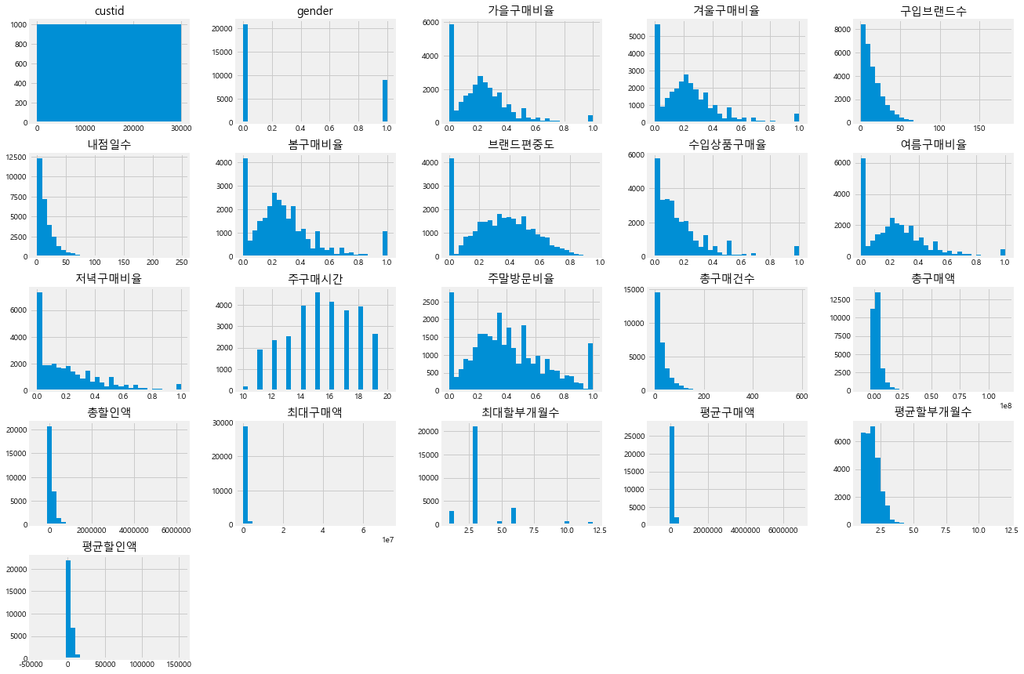

```python
train.hist(bins=30, figsize=(20,15))
```

<font color = "#3232FF">

## 기존 데이터에 존재하는 변수들을 유형별로 구분해보았다.

- '총구매액','Continous'
- '총구매건수','Continous'
- '평균구매액','Continous'
- '최대구매액','Continous'
- '총할인액','Continous'
- '평균할인액','Continous'
- '평균할부개월수','Continous'
- '최대할부개월수', 'Continous'
- '구입브랜드수', 'Continous'
- '브랜드편중도', 'Continous'
- '수입상품구매율', 'Continous'
- '내점일수', 'Continous'
- '주말방문비율', 'Continous'
- '봄구매비율', 'Continous'
- '여름구매비율', 'Continous'
- '가을구매비율', 'Continous'
- '겨울구매비율', 'Continous'
- '저녁구매비율', 'Continous'
- '주구매브랜드', 'Categorical'
- '주구매코너', 'Categorical'
- '주구매시간', 'Continous'
- '주방문요일', 'Categorical'
- 'gender' , 'Categorical' & ***Target

<font color = "#3232FF">

## 2-1. Gender

```python
print ('남성 :' ,round((sum(train['gender'])/len(train.gender))*100,2) , '여성 :' ,100 - round((sum(train['gender'])/len(train.gender))*100,2))
```

```
남성 : 30.39 여성 : 69.61
```

<font color = "#3232FF">

목표타겟인 gender가 굉장히 편중된 데이터라는 것을 알 수 있다.

이 점을 유념해 데이터탐색을 진행해야한다.

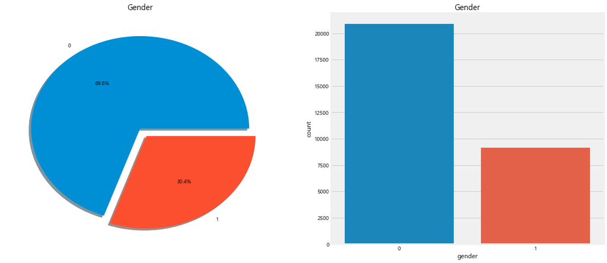

```python
f,ax=plt.subplots(1,2,figsize=(18,8))
train['gender'].value_counts().plot.pie(explode=[0,0.1],autopct='%1.1f%%',ax=ax[0],shadow=True)
ax[0].set_title('Gender')
ax[0].set_ylabel('')
sns.countplot('gender',data=train,ax=ax[1])
ax[1].set_title('Gender')
plt.show()
```

<font color = "#3232FF">

# 2-2. 주방문요일 & Gender

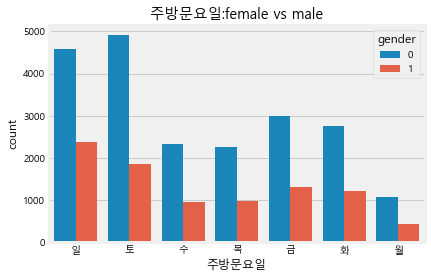

```python
sns.countplot('주방문요일',hue='gender',data=train).set_title('주방문요일:female vs male')
plt.show()
```

<font color = "#3232FF">

전체적으로 일주일 전반적인 방문수의 흐름은 비슷하다 .

남녀 모두 월요일에 방문수가 적고 그다음 수,목 그리고 화,금 , 주말의 패턴을 보인다.

그러나 전반적인 흐름이 비슷하고, 약간의 차이를 꼬집어 봤을 때 찾을 수 있을 뿐, 이를 가지고 남녀를 분별할 수 있다고 보긴 어렵다.

<font color = "#3232FF">

# 주구매브랜드 & Gender

```python
train['주구매브랜드'].nunique()
```

```
1103
```

<font color = "#3232FF">

주구매브랜드의 고유한 값이 1103개 이기에 모든 데이터를 한번에 시각화 하는 것은

유의미한 결과를 가져오기 어렵기 때문에 상위10개항목을

성별에 따라 분류하여 데이터를 탐색해보았다.

```python
a = train.groupby(['gender','주구매브랜드'],as_index=False).count()
a = a[['gender','주구매브랜드','custid']]
female_brand = a[a['gender']==0].sort_values(by=['custid'],axis=0,ascending=False).head(10)
male_brand = a[a['gender']==1].sort_values(by=['custid'],axis=0,ascending=False).head(10)

female_brand
```

|  | gender | 주구매브랜드 | custid |
| --- | --- | --- | --- |
| 589 | 0 | 식품 | 7222 |
| 263 | 0 | 랑콤 | 746 |
| 887 | 0 | 크리니크 | 427 |
| 678 | 0 | 에스티로더 | 415 |
| 851 | 0 | 지오다노 | 362 |
| 514 | 0 | 샤넬 | 358 |
| 624 | 0 | 아모레 | 350 |
| 358 | 0 | 메이컵포에버 | 301 |
| 487 | 0 | 비오뗌 | 275 |
| 625 | 0 | 아베다 | 253 |

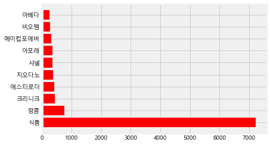

```python
plt.barh(female_brand['주구매브랜드'],female_brand['custid'] ,color='r',tick_label='')
plt.yticks(np.arange(10),female_brand['주구매브랜드'])
plt.show()
```

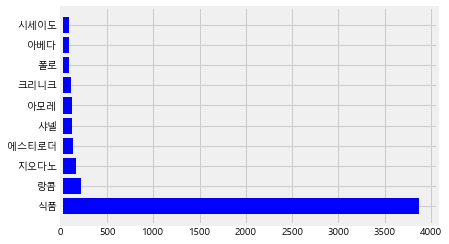

```python
plt.barh(male_brand['주구매브랜드'],male_brand['custid'] ,color='b',tick_label='')
plt.yticks(np.arange(10),male_brand['주구매브랜드'])
plt.show()
```

<font color = "#3232FF">

주구매 브랜드는 남녀 모두 식품에서 가장 높게 나타나고 있다.

이 변수 또한 남녀를 구분짓는데 큰 영향을 보이지 않는다.

<font color = "#3232FF">

# 주구매코너 & Gender

```python
train['주구매코너'].nunique()
```

```
272
```

```python
a = train.groupby(['gender','주구매코너'],as_index=False).count()
a = a[['gender','주구매코너','custid']]
female_corner = a[a['gender']==0].sort_values(by=['custid'],axis=0,ascending=False).head(10)
male_corner = a[a['gender']==1].sort_values(by=['custid'],axis=0,ascending=False).head(10)

female_corner
```

|  | gender | 주구매코너 | custid |
| --- | --- | --- | --- |
| 127 | 0 | 수입종합화장품 | 6379 |
| 168 | 0 | 용기보증 | 2172 |
| 160 | 0 | 영캐주얼 | 1072 |
| 208 | 0 | 진캐쥬얼 | 664 |
| 89 | 0 | 미확인코너 | 635 |
| 68 | 0 | 란제리 | 511 |
| 149 | 0 | 아동복 | 464 |
| 220 | 0 | 캐릭터 | 396 |
| 147 | 0 | 아동 | 320 |
| 163 | 0 | 영트랜드 | 303 |

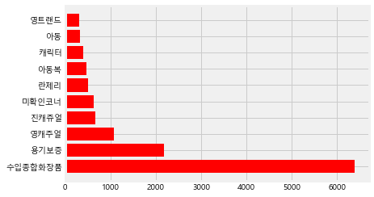

```python
plt.barh(female_corner['주구매코너'],female_corner['custid'] ,color='r',tick_label='')
plt.yticks(np.arange(10),female_corner['주구매코너'])
plt.show()
```

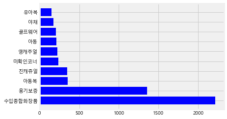

```python
plt.barh(male_corner['주구매코너'],male_corner['custid'] ,color='b',tick_label='')
plt.yticks(np.arange(10),male_corner['주구매코너'])
plt.show()
```

<font color = "#3232FF">

주구매코너 또한 앞서 설명한 주구매브랜드와 비슷한 양상을 보인다.

수입종합화장품과 용기보증이 남녀 모두에서 높은 빈도를 보이는데 순서와 남녀 각각에서의 전체적 비율또한 비슷하다.

그리고 그래프에 보이는 나머지 7코너 중 5개가 겹치고 7개의 빈도는 상대적으로 매우 작다는 점에서

주구매 코너 또한 남녀 구별에 큰 영향을 끼치는 변수로 보이지 않는다.

<font color = "#3232FF">

# 주구매시간 & Gender

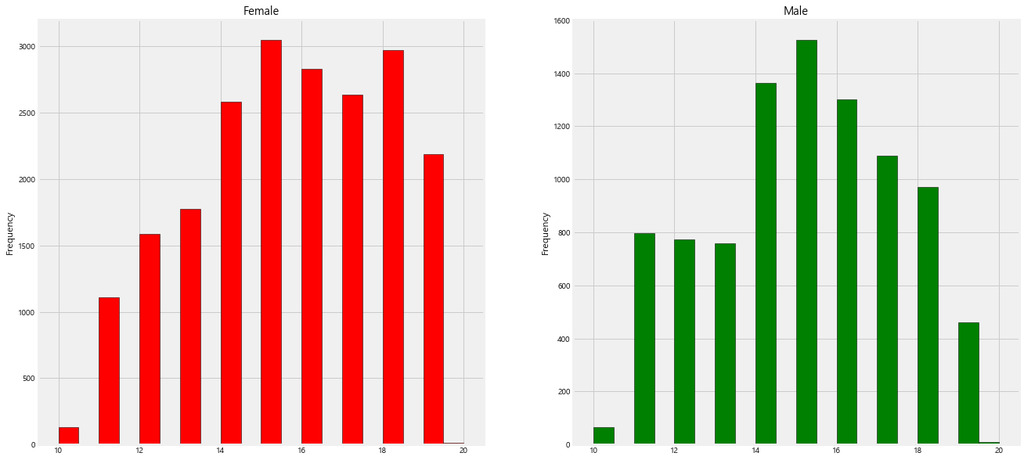

```python
f,ax=plt.subplots(1,2,figsize=(20,10))
train[train['gender']==0].주구매시간.plot.hist(ax=ax[0],bins=20,edgecolor='black',color='red')
ax[0].set_title('Female')
train[train['gender']==1].주구매시간.plot.hist(ax=ax[1],color='green',bins=20,edgecolor='black')
ax[1].set_title('Male')
plt.show()
```

<font color = "#3232FF">

주구매시간을 보면 여자는 11~13시에 빈도가 상승하는 모양인데 반해 남자는 아주 작은 양이지만 상대적으로 감소하는 기울기는 보인다.

그리고 여성은 18시에 2번째로 높은 빈도를 보이는 데 반해 남성은 그에반해 낮은 빈도를 보인다.

그러나 둘다 15시에 가장 높은 빈도를 보이고 있다. 전체적으로 봤을 때 주구매시간은 남녀의 시간대에 따른 빈도의 차이가 보이는 것으로 보아.

남녀의 주구매시간은 차이가 존재함을 의미하고, 이는 주구매시간 변수가 남녀 구분에 영향을 끼치는 것으로 판단된다.

<font color = "#3232FF">

# 상관계수 행렬

- 범주형변수를 제외하고 각 변수끼리의 상관계수 행렬을 보았다.

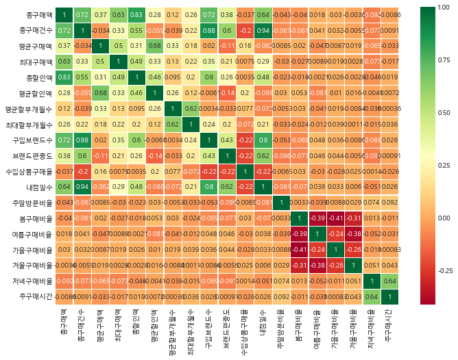

```python
train_cor = train.drop(['custid','주방문요일','주구매코너','주구매브랜드','gender'],axis=1)

sns.heatmap(train_cor.corr(),annot=True,cmap='RdYlGn',linewidths=0.2)
fig=plt.gcf()
fig.set_size_inches(10,8)
plt.show()
```

<font color = "#3232FF">

# 다변량 그래프

- 성별에 영향을 어느정도 미친다고 예측되는 범주형 변수와 연속형 변수를 성별에 따라 구분해 보았지만

  만족스러운 결과를 즉, 성별에 영향을 미친다고 생각되지 않는다.

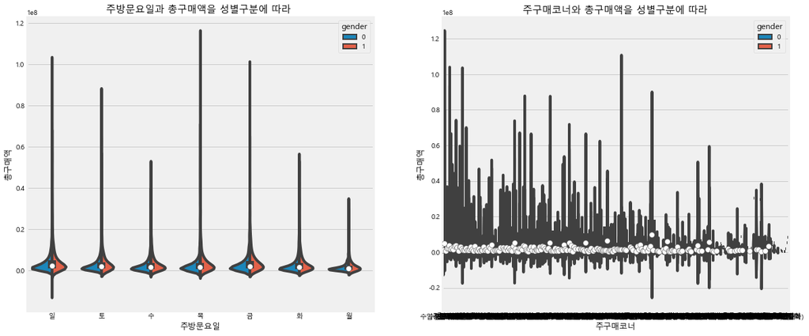

```python
f,ax=plt.subplots(1,2,figsize=(18,8))
sns.violinplot("주방문요일","총구매액", hue="gender", data=train,split=True,ax=ax[0])
ax[0].set_title('주방문요일과 총구매액을 성별구분에 따라 ')
sns.violinplot("주구매코너","총구매액", hue="gender", data=train,split=True,ax=ax[1])
ax[1].set_title('주구매코너와 총구매액을 성별구분에 따라')
plt.show()
```

<font color = "#3232FF">

# 총구매액

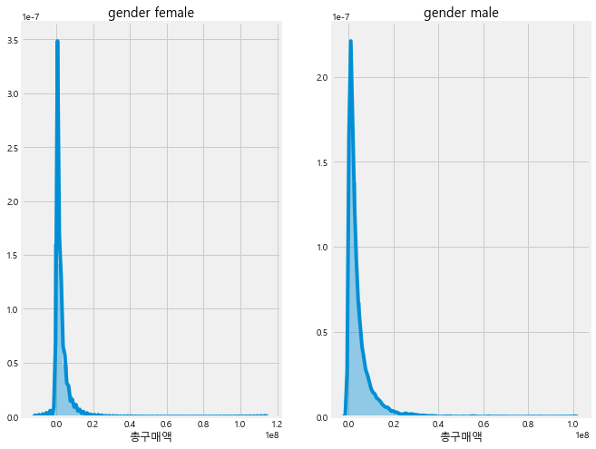

```python
f,ax=plt.subplots(1,2,figsize=(10,8))
sns.distplot(train[train['gender']==0].총구매액,ax=ax[0])
ax[0].set_title('gender female')
sns.distplot(train[train['gender']==1].총구매액,ax=ax[1])
ax[1].set_title('gender male')
plt.show()
```

<font color = "#3232FF">

총구매액은 남녀 분포가 아주 유사한 모양을 보이고 있다. 다만 여자 그래프가 남자에 반해 높이가 높은데,

이는 여자가 남자에 비해 더 많이 돈을 쓴다라고 판단할 수 없다. 맨 처음에 보았듯, 이 데이터는 남녀의 비중이 3:7로 여자데이터가 남자데이터보다

양적으로 훨씬 많다,그렇기 떄문에 이러한 데이터의 양차이를 고려해 보았을 때, 높이차는 당연한 현상이며 비슷한 분포를 보이는 것으로 보아

남녀의 총구매액의 차이는 딱히 없는 것으로 보인다. 그런데, 남녀의 데이터 양의 차이는 여자가 남자의 2.3배 정도인데

따라서, 남자의 구매액이 전체적으로 여자보다 많구나라고 생각이 드는데, 이것만 보고 확단하긴 이르므로 후에 나오는 평균 구매액을 보고 정확한 판단이 필요하다.

<font color = "#3232FF">

# 총구매건수

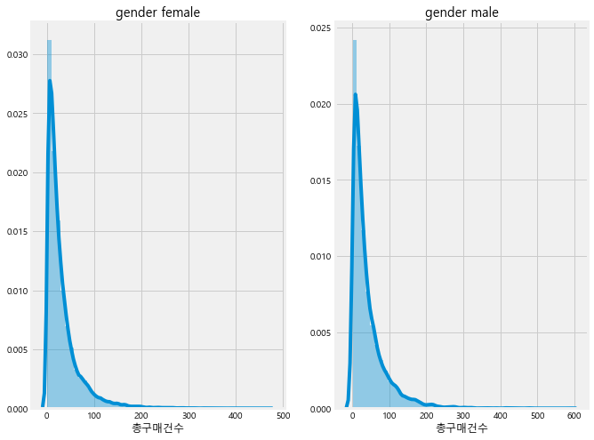

```python
f,ax=plt.subplots(1,2,figsize=(10,8))
sns.distplot(train[train['gender']==0].총구매건수,ax=ax[0])
ax[0].set_title('gender female')
sns.distplot(train[train['gender']==1].총구매건수,ax=ax[1])
ax[1].set_title('gender male')
plt.show()
```

<font color = "#3232FF">

총 구매건수 또한 앞의 총구매액과 매우 유사하다. 남녀에서의 양상이 같다.

남녀 그래프에서의 높이차는 데이터양의 차이라고 판단된다. 그러나 이 그래프 또한 앞의 변수와 마찬가지로 데이터 자체의 남녀 비중차이에 비해 작다.

이를 좀더 깊이 알아보고자, 총구매건수를 총구매액으로 나눈 값을 알아보았다.

총 구매건수를 x축, 총구매액을 y축으로 두고 산점도를 그렸더니 남녀에서 점이 찍힌 전체적인 기울기가 다르다.

남성이 더 가파른데, 즉 남성이 구매건수는 적지만 구매액은 더 많다는 것을 의미한다.

이를 통해 남자가 여자보다 구매건수는 적지만 구매액은 더 높다는 소비양상을 약간은 알 수 있다.

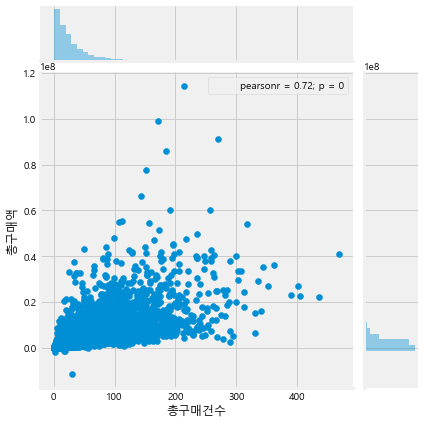

```python
sns.jointplot(x=train[train['gender']==0].총구매건수, y=train[train['gender']==0].총구매액, data=train, kind='scatter') #산점도, 각각 변수의 히스토그램 볼 수 있음.
plt.show()
```

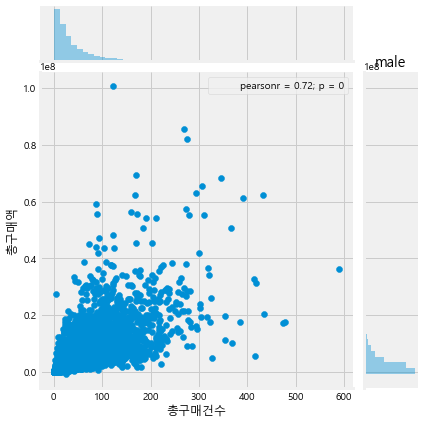

```python
sns.jointplot(x=train[train['gender']==1].총구매건수, y=train[train['gender']==1].총구매액, data=train, kind='scatter') #산점도, 각각 변수의 히스토그램 볼 수 있음.
plt.title('male')
plt.show()
```

<font color = "#3232FF">

# 평균구매액

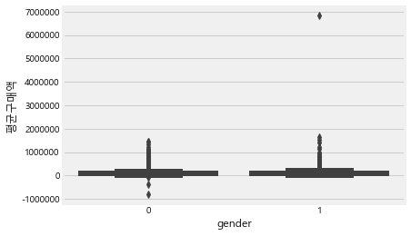

```python
sns.boxplot(y=train.평균구매액,x='gender',data=train)
plt.show()
```

<font color = "#3232FF">

앞에서 변수 총구매액을 볼 때 남자가 여자에 비해 데이터가 2배가 좀 넘게 적음에도 불구하고

평균 구매액을 보았더니, 남녀 의 평균과 분포적인 박스 플랏은 거의 비슷하다. 그러나 남자 데이터는 엄청난 이상치가 하나 존재한다.

즉, 우리의 앞선 생각, 남자가 여자보다 많이 돈을 쓴다는 생각은 사실이 아니며, 엄청난 이상치고 인한 결과로 판단된다.

이 이상치는 심각하게 떨어져 있어, 전체적인 데이터의 양상을 흔들어 놓는다.

따라서, 이 이상치는 후에 모델링을 하기 앞서 제거하는 것이 바람직하다고 판단된다. 또한, 이를 통해, 총구매액과 평균구매액은 모두 남녀에서 거의 비슷한 양상을 띄므로 남녀 구별에 영향을 끼치지 않는 변수이다.

```python
train[train['평균구매액']>6000000]
train=train.drop(26557,0)
```

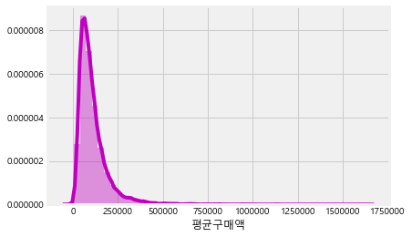

```python
sns.distplot(train[train['gender']==1].평균구매액, hist=True,  color="m")
plt.show()
```

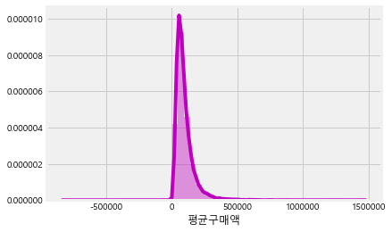

```python
sns.distplot(train[train['gender']==0].평균구매액, hist=True, color="m")
plt.show()
```

<font color = "#3232FF">

# 최대구매액

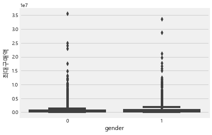

```python
sns.boxplot(y=train.최대구매액,x='gender',data=train)
plt.show()
```

<font color = "#3232FF">

최대구매액 또한 앞의 평균구매액과 마찬가지로 평균과 분포의 박스플랏은 거의 유사하다.

그러나 여성 데이터에서 중심과 많이 동떨어진 데이터가 존재하는 데 이는 데이터의 전체적 양상을 다르게 보이게 할 수 있으므로 제거함이 바람직하다.

```python
train[train['최대구매액']>70000000]
train=train.drop(12593,0)
```

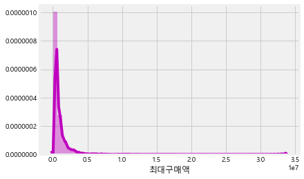

```python
sns.distplot(train[train['gender']==1].최대구매액, hist=True, color="m")
plt.show()
```

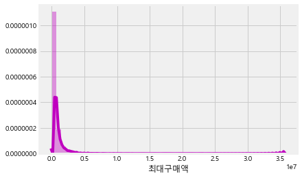

```python
sns.distplot(train[train['gender']==0].최대구매액, hist=True,  color="m")
plt.show()
```

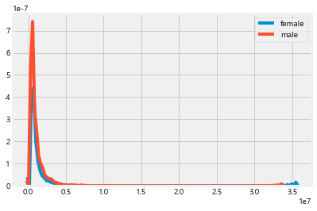

```python
sns.kdeplot(train[train['gender']==0].최대구매액,label='female') #확률밀도함수
sns.kdeplot(train[train['gender']==1].최대구매액,label='male')
plt.show()
```

<font color = "#3232FF">

즉, 최대구매액은 남녀구별에 큰 영향을 끼치지 않을것으로 보인다.

<font color = "#3232FF">

# 총할인액

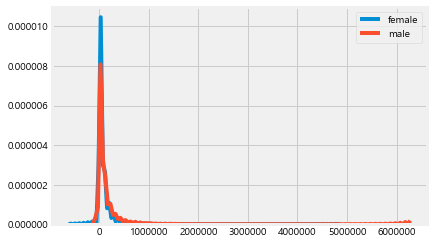

```python
sns.kdeplot(train[train['gender']==0].총할인액,label='female') #확률밀도함수
sns.kdeplot(train[train['gender']==1].총할인액,label='male')
plt.legend()
plt.show()
```

<font color = "#3232FF">

총할인액 그래프를 보면 남녀가 비슷한 양상을 보인다. 좀 더 자세히 보기 위해 확대해 보았다.

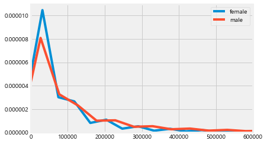

```python
sns.kdeplot(train[train['gender']==0].총할인액,label='female') #확률밀도함수
sns.kdeplot(train[train['gender']==1].총할인액,label='male')
plt.xlim([-500,600000])
plt.legend()
plt.show()
```

<font color = "#3232FF">

여자가 50000대에서 남자보다 높은 빈도를 보였지만, 80000이후 대에는 모두 남자가 여자보다 높은 빈도를 보인다.

50000대의 차이, 여자가 남자보다 높이 나타나는 것은 여자 데이터가 남자데이터보다 많기 때문에 나타나는 것으로 보이며, 이후 남자가 여자보다 높은 것으로 보아. 이는 남자가 여자보다 할인을 더 많이 받음을 알 수 있다.

즉, 여자 데이터가 남자데이터보다 훨씬 많아 일반적으로 여자가 남자보다 높거나 많이 나타날 수 있는 상황에서 남자가 더 큰 양상으로 보이는 총 할인액은 일반적인 상황과 달리 남자 소비자의 독특한 상황을 보여주는 변수로 남녀를 구분짓는데 역할을 할 것 같다.

<font color = "#3232FF">

# 평균할인액

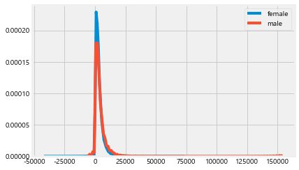

```python
sns.kdeplot(train[train['gender']==0].평균할인액,label='female') #확률밀도함수
sns.kdeplot(train[train['gender']==1].평균할인액,label='male')
plt.legend()
plt.show()
```

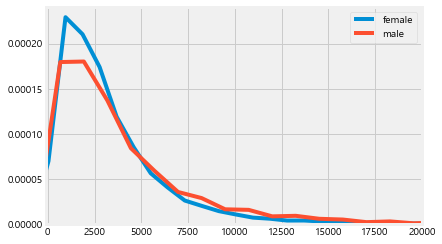

```python
sns.kdeplot(train[train['gender']==0].평균할인액,label='female') #확률밀도함수
sns.kdeplot(train[train['gender']==1].평균할인액,label='male')
plt.legend()
plt.xlim([-100,20000])
plt.show()
```

# 평균할부개월수

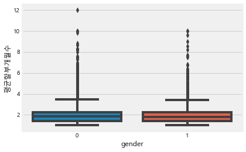

```python
sns.boxplot(y=train.평균할부개월수,x='gender',data=train)
plt.show()
```

<font color = "#3232FF">

평균할부개월수 플랏을 보면 남녀가 거의 같은 비슷한 모양이다.

```python
train[train['평균할부개월수']>11]
train=train.drop(10717,0)
```

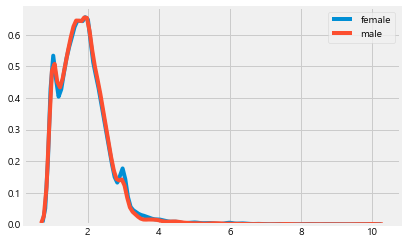

```python
sns.kdeplot(train[train['gender']==0].평균할부개월수,label='female') #확률밀도함수
sns.kdeplot(train[train['gender']==1].평균할부개월수,label='male')
plt.legend()
plt.show()
```

<font color = "#3232FF">

<font color = "#3232FF">평균할부개월수의 남녀 데이터 양상이 매우 비슷하다 1,3월에서의 약간의 차이는 남녀 데이터 차이로 인한 차이로 판단된다.

<font color = "#3232FF">

# 최대할부개월수

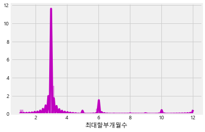

```python
sns.distplot(train[train['gender']==0].최대할부개월수, hist=True, color="m")
plt.show()
```

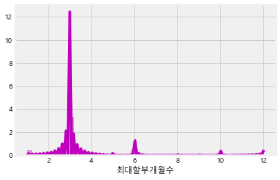

```python
sns.distplot(train[train['gender']==1].최대할부개월수, hist=True,color="m")
plt.show()
```

<font color = "#3232FF">

남녀의 최대할부개월수를 따로 그려보았더니 , 거의 같은 그래프인가 싶을 정도로 같은 모양을 보인다.

그래서 이를 정확히 알아보기 위해 한 플랏에 한번에 그려보았다.

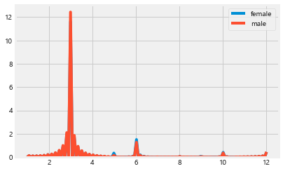

```python
sns.kdeplot(train[train['gender']==0].최대할부개월수,label='female') #확률밀도함수
sns.kdeplot(train[train['gender']==1].최대할부개월수,label='male')
plt.legend()
plt.show()
```

<font color = "#3232FF">

<font color = "#3232FF">거의 겹쳐질 정도로 두 데이터의 분포 양상은 비슷하다. 따라서, 최대할부개월수는 남녀를 분별함에 영향을 미치지 않을 것으로 보인다.

<font color = "#3232FF">

# 구입브랜드수

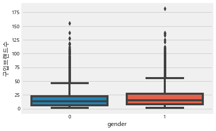

```python
sns.boxplot(y=train.구입브랜드수,x='gender',data=train)
plt.show()
```

<font color = "#3232FF">

구입브랜드 수 박스플랏을 보면 남자 데이터에서 중심과 동떨어진 이상치가 보인다.

이는 앞서 내내 말했던 이유와 같은 이유로 제거하였다. 그리고 박스의 분포를 보면 남자가 여자보다 높게 그려져 있다.

이는 남자가 여자보다 평균적으로 더 다양한 브랜드의 제품을 구매함을 의미한다.

```python
train[train['구입브랜드수']>175]
train=train.drop(13376,0)
```

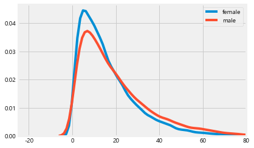

```python
sns.kdeplot(train[train['gender']==0].구입브랜드수,label='female') #확률밀도함수
sns.kdeplot(train[train['gender']==1].구입브랜드수,label='male')
plt.legend()
plt.xlim([-25,80])
plt.show()
```

<font color = "#3232FF">

빈도플랏으로 보니 0~10사이에 보이는 여성이 더 높이 그려진 양상은 남녀 데이터 양적 차이에서 비롯되었다고 보인다.

20이후에 남자가 여자보다 높은 빈도를 보이는데, 이는 확실히 남자가 여자보다 다양한 브랜드의 제품을 구매함을 의미한다.

# 브랜드편중도

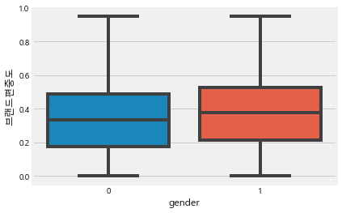

```python
sns.boxplot(y=train.브랜드편중도,x='gender',data=train)
plt.show()
```

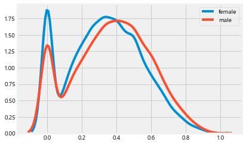

```python
sns.kdeplot(train[train['gender']==0].브랜드편중도,label='female') #확률밀도함수
sns.kdeplot(train[train['gender']==1].브랜드편중도,label='male')
plt.legend()
plt.show()
```

<font color = "#3232FF">

브랜드 편중도도 브랜드구매수와 비슷한 모습이다.

이 또한, 0.4까지 보이는 여자가 남자보다 높은 빈도를 나타내는 것은 여자 데이터가 남자데이터보다 양적으로 많기 때문이고,

0.4이후에는 데이터 양적 차이에도 불구하고 남자가 여자보다 높이 나타난다.

편중도가 높은 부분에서 남자가 여자보다 더 높이 나타남은 남자가 여자보다 브랜드 편중도가 높다는 의미이다.

이는 남녀의 차이가 해석되므로, 남녀 구별에 영향을 미친다고 생각된다.

<font color = "#3232FF">

# 수입상품구매율

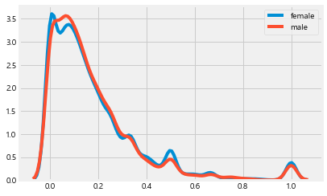

```python
sns.kdeplot(train[train['gender']==0].수입상품구매율,label='female') #확률밀도함수
sns.kdeplot(train[train['gender']==1].수입상품구매율,label='male')
plt.legend()
plt.show()
```

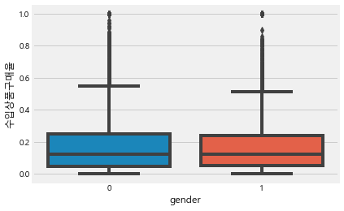

```python
sns.boxplot(y=train.수입상품구매율,x='gender',data=train)
plt.show()
```

<font color = "#3232FF">

<font color = "#3232FF">수입상품구매비율은 빈도함수와 박스플랏 모두 매우 비슷한 양상을 보인다.

수입상품 구매비율로 남녀간의 어떠한 차이가 발견되지 않는다.

따라서 수입상품구매비율로 남녀가 구분되지 않을 것이다.

<font color = "#3232FF">

# 내점일수

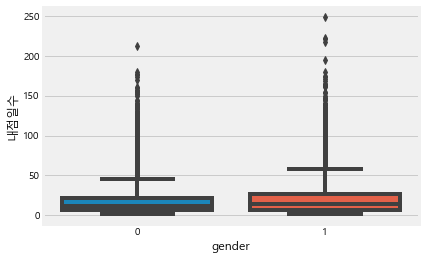

```python
sns.boxplot(y=train.내점일수,x='gender',data=train)
plt.show()
```

<font color = "#3232FF">

내점일수 박스플랏은 비슷한 양상을 보인다. 남성에서 중심과 멀리 떨어진 이상치가 보여 앞선 이유와 동일한 이유로 제거하였다.

```python
train[train['내점일수']>230]
train=train.drop(20439,0)
```

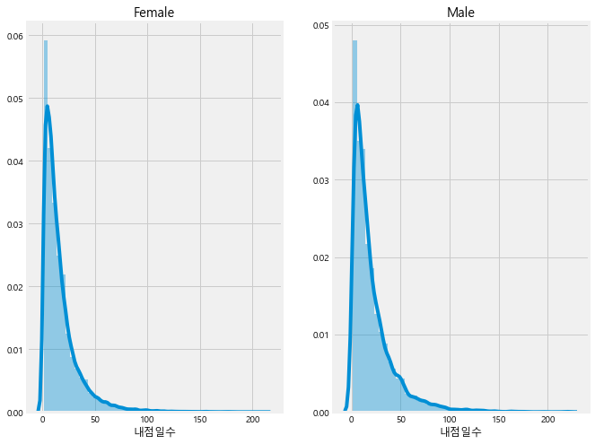

```python
f,ax=plt.subplots(1,2,figsize=(10,8))
sns.distplot(train[train['gender']==0].내점일수,ax=ax[0])
ax[0].set_title('Female')
sns.distplot(train[train['gender']==1].내점일수,ax=ax[1])
ax[1].set_title('Male')
plt.show()
```

<font color = "#3232FF">

내점일수의 분포는 거의 비슷하다. 내점일수에 대한 남녀의 차이는 발견되지 않는다. 따라서, 내점일수로 남녀를 구분하기는 힘들것 같다.

<font color = "#3232FF">